# `moms`: measuring occupancy in multidimensional spaces

Thomas Guillerme

2021-07-20

## Introduction

`moms` is a Shiny app for helping choosing the right tool for measuring occupancy in multidimensional spaces.

**Multdimensional spaces** are any space with multiple dimensions as columns (usually -but not necessary - more than 3 dimensions) and observations (or elements) as rows. Such multidimensional spaces are called differently in different fields in biology (and beyond) but they are often trait-spaces in ecology or morphospaces in macroevolution.

**Space-occupancy metrics** are indices that measure how the observations (data points) are distributed in the trait-space. They also have different names in different fields, they have been called dissimilarity indices (ecology) or disparity metrics (evolution).

One problem is that these space-occupancy metrics can be non-intuitive, especially in high dimensional spaces and can capture different aspects of space-occupancy (volume, density or position). `moms` allow to simulate or import multidimensional spaces and test and visualise the effect of specific metrics on the multidimensional space occupancy. It also allows to disrupt the space to check how the metric responds to changes in the distribution of the observations.

### What `moms` is *not*?

A tool for analysing multidimensional data. `moms` is a tool for helping to choose multidimensional space occupancy metrics, it should not be used to actually analyse the spaces. If you want to analyse multidimensional spaces, we suggest you use the many `R` packages available: [`dispRity`](https://cran.r-project.org/web/packages/dispRity/index.html), [`vegan`](https://cran.r-project.org/web/packages/vegan/index.html) or [`Momocs`](https://cran.r-project.org/web/packages/Momocs/index.html) or whatever tools suits you best!

### Potential bugs

`moms` is a software that is continually updated (and tested!) it can therefore contain some bugs. If you find any such bug or if there is a feature that you would like to see in the next version of the software, please email me (guillert@tcd.ie) or if you are a GitHub user, directly create an issue on the [GitHub page](https://github.com/TGuillerme/moms). This really helps developing the software further and will be useful to other users!

## The basics

This is what `moms` looks like:

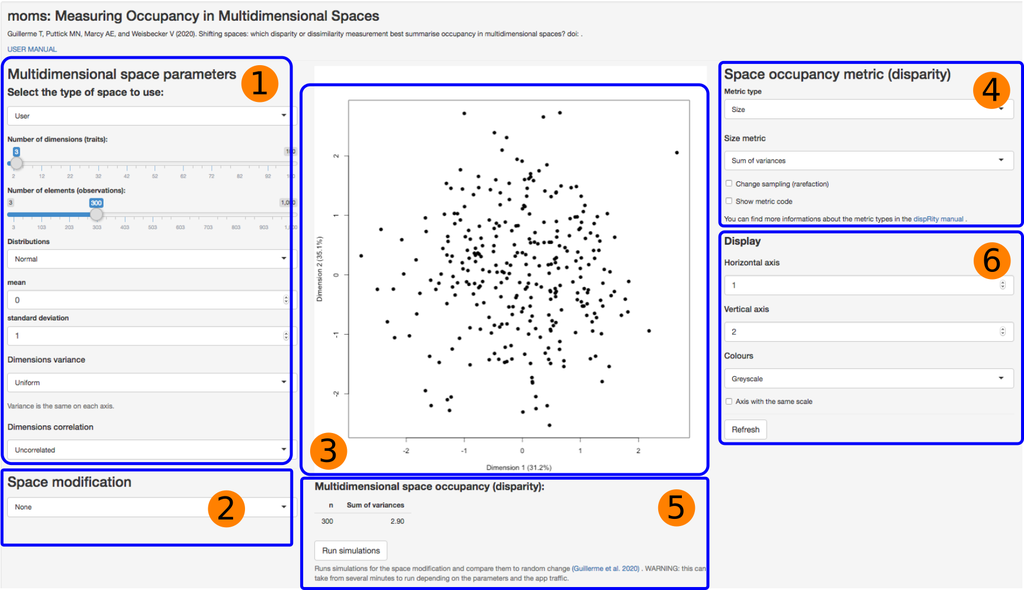

Figure 1: `moms` interface

It is then possible to explore either the effect of the space modification on different metrics by changing the metric (until you find the one that suits your question) or by changing the space modification (until you find what type of space modification the metric measures, or not).

### Creating a space

The easiest way is to let `moms` create a space for you you can chose the number of dimensions and the number of observations using the sliders. You can do this using the `"User"` option in the space generation panel (1):

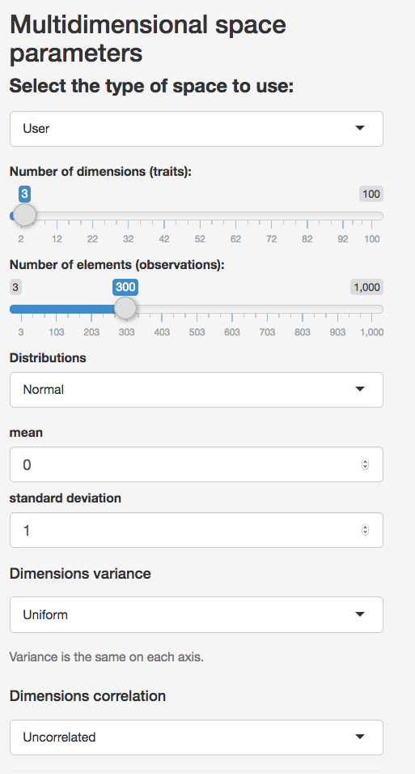

Figure 2: setting the space parameters

This panel allows to select:

1. The **number of observations** (simulating the number of species, field sites, etc...).
2. The **number of dimensions** (the number of traits).
3. The **distribution** of traits see this specific section for more info.
4. The **dimensions variance** to specify how much variance should be on each dimensions. This can be done to simulate principal components analysis (PCA) for example where the distribution of variance per dimensions tends to decrease log-normally.
5. The **dimensions correlation** allowing to set some correlation between the distributions. This can be done by inputting a vector of correlations between each distributions, filling a correlation matrix or uploading a personalised correlation matrix.

You can visualise the resulting space in the space panel (3).

> **Importing spaces**: Note that you can also import your own space using `"Input"` in the "Select the type of space to use type" menu. This will open a navigation window allowing you to select a `.csv` matrix on your machine. The matrix must contain only numeric values and must have row and column names.

> **Using demo spaces**:Finally it is also possible to use demo data by selecting `"Demo"` in the "Select the type of space to use type" menu. You can then choose across six diverse published empirical multidimensional spaces from ranging from palaeontology to ecology. Information about the empirical multidimensional spaces is displayed once you select any (i.e. what is the space capturing?) along with the reference of the original publication for more informations.

#### Trait distributions

The traits can be `"Normal"`, `"LogNormal"`, `"Uniform"`, `"Gamma"`, `"Poisson"` or `"Specific"`. For each of these option (expect `"Specific"`), it is possible to set the distribution parameters (e.g. the mean and the standard deviation for a normal distribution). When using the `"Specific"` option, you can input different specific distributions as random distribution functions from the `stats` package in `R`. For example, if you want a five dimensional space with two normal traits, two uniform ones and one gamma, you can use the following `"Specific"` option:

```
list(rnorm, rnorm, runif, runif, rgamma)
```

Note that you can fine tune each of these distribution by giving them specific parameters by ticking the `"Optional arguments"` button and enter a list of arguments. Use an empty list (`list()`) for empty (default) arguments. For the example above, if we want all the distributions to be default but the uniform ones to be bounded between -1 and 1, we can use:

```
list(list(), list(), list(max = 1, min = -1), list(max = 1, min = -1), list())
```

Note that the order of the arguments does not matter as long as they are named. To check the available arguments, refer to the specific function in the `R` manual (e.g. `?rpoisson`).

### Modifying the space

Once a space is parametrised (or imported), it is possible to modify it by selecting a modification algorithm in the "Space modification" menu.

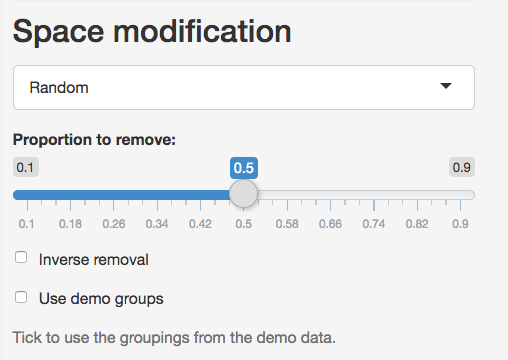

Figure 3: reducing the space

For each removal algorithm, you can choose the proportion of elements to remove using the "Proportion to remove" sliding bar (between 10% and 90%). It is also possible to use the "Inverse removal" button to inverse the selection: for example if you randomly remove 33% of the elements, ticking this option will keep the 33% selected elements (i.e. remove 66% others).

> If you are using the demo datasets, you can also choose to select the groupings used for the demo datasets which will automatically generate empirical groups. Details on the groups is given when ticking this option.

You can visualise the resulting modification in the space panel (3).

### Measuring space occupancy

You can then select which space occupancy metric to apply to the global space and its modification in the metric panel (4). This panel is also called "Disparity" since this is the term mostly used in palaeobiology. It can be referred to as "Dissimilarity" in ecology or as space occupancy in general.

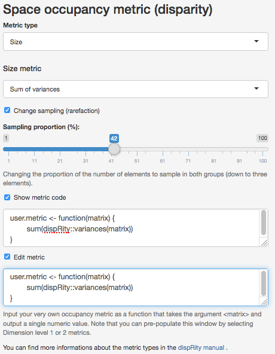

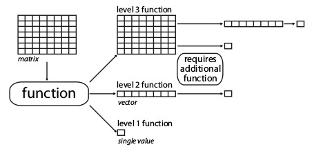

Figure 5: metrics dimensions levels

This allows you to combine different metrics, for example, the sum (dimension level 1) of the variances of each column of the matrix (dimension level 2).

You can visualise the metric values in the space occupancy panel (5).

#### Sampling

It is also possible to look at the effect of sampling by ticking the `"Change sampling (rarefaction)"` box. This will display a slider allowing you to select the number of elements you want to sample for the overall space or for the reduced space. The sampling uses the bootstrap procedure from the `dispRity::boot.matrix()` function and allows to reduce the number of elements by performing 100 bootstraps and resampling `n` elements each time (from the sampling proportion value on the slider). Note that the proportion of elements sampled is determined by the size of the reduced subset. For example in a multidimensional space with 300 elements and a randomly reduced subset including 50% of elements (150), 100% sampling corresponds to 150 elements, 50% sampling to 75 elements, etc...

### Results and simulations

Once all the options carefully selected to correspond to your analysis and biological question, you can see the resulting displays in the result panel (5).

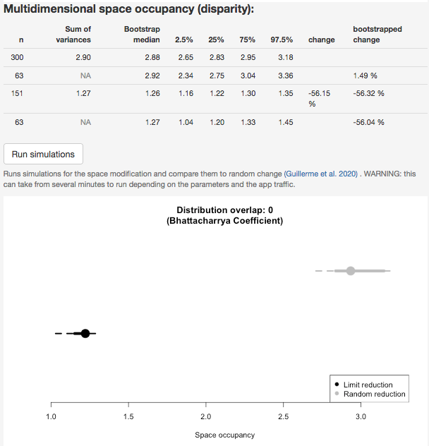

Figure 6: results panels with sampling and simulations.

#### Simulations

It is also possible, when parametrising a user input space (see space section above), to simulate how does your chosen space occupancy metric compares in a selected reduced space to a random one. This option can take several minutes to run depending on the shiny apps sever traffic (or your machine if you're running the locally). The results will are displayed in a graph and show the proportion of overlap between the space occupancy in the reduced space (bottom in Fig. 6) and the ones from a random removal (top in Fig. 6). The more these distributions overlap (measured by the Bhattacharrya Coefficient), the more likely your metric will pick up random signal rather than the real signal from your reduction.

#### Testing the metric

If you want you can also test the effect of the space modification on the metric score by using the inbuilt `dispRity::test.metric` function (much faster but may be less precise). You can find all about how the `dispRity::test.metric` works [here](https://raw.githack.com/TGuillerme/dispRity/master/inst/gitbook/_book/details-of-specific-functions.html#which-disparity-metric-to-choose) but basically a slope indicates a change in metric score and a "flat" line indicates no change.

### Changing the display

Finally, you can modify the display of space panel (3) by using the display panel (6). This one allows to select which axis (dimensions) to be displayed, what colour palette to use and finally whether to scale the axis or not. This latest option can be useful when dimensions don't have the same variance.

## `moms` and `dispRity`

`moms` is based on the [`dispRity`](https://cran.r-project.org/web/packages/dispRity/index.html) package. You can find every space occupancy metrics in the `dispRity` package by looking for the `?dispRity::dispRity.metric` manual. The simulated spaces on the other hand are generated using the `?dispRity::space.maker` function. You can find much more information about both sets of functions in the [`dispRity` manual](https://tguillerme.github.io/dispRity.html).